# Examining NOM-INS construction in Russian

```r
library(randomForest)
require(caTools)
library(knitr)
library(factoextra)
library(ca)
library(caret)
library(ROCR)
```

## 1. Data description

Current project is based on the pre-collected [dataset](https://dataverse.no/dataset.xhtml?persistentId=doi:10.18710/ZAM96S&version=1.0) from Russian National Corpus. The authors of the dataset are Tore Nesset, Laura A. Janda and Mihail Kopotev. The objective of the dataset and my project is to examine NOM-INS construction in Russian like *“дурак дураком”* and *“вода водой”*.

This dataset consists of two parts: the first one examines **plural forms** of such constructions and the second one – **singular forms**. Both parts have the same set of features:

- semantics of the construction (*abundance, extreme, instrument, paragon, and topic change*)
- syntactic role of the noun (*Ins verb-governed, Nom verb-governed, Nom/Ins verb governed and Ungoverned*)
- semantic classes of nouns (*abstract, concrete, human + animal, substances*)
- pejorative (*as involving or not involving a pejorative nuance*)
- chained (*marks cases with 2+ occurrences of constructions*)
- associated verb
- left and right contexts
- construction itself
- punctuation marks immediately following the construction
- metadata (*title of the work, name and birthday of the author, header, year of creation, “sphere” and “type” of the text, topic, publication name and year*)
- full context

This list of features will be expanded. Primarily, the morphological parameters of the associated verb are going to be added. Also, using context and morphology, I am going to create morphological patterns of the construction’s usage.

My goal is to examine what features have the best correlation to the semantics of the construction. I will use decision trees and linear regression models to achieve this. The hypothesis is that syntactic role and semantic class of nouns will be most relevant features for the construction classification.

Let’s formulate the hypotheses more formally.

H_0: `Semantics` feature is independent and do not correlate with other features. H_1: `Semantics` feature is not independent and correlates with some other features. H_2: `Syntax` and `Semantic_Classes_Of_Nouns`are the best predictors for the `Semantics` feature.

## 2. Data prepricessing

### 2.1. Python

The datasets are preprocessed via python, full notebook with the code can be found [here](https://github.com/mkilina/ling_data_project/blob/master/data_preprocessing.ipynb).

What was added:

- columns `Left_context_tags` and `Right_context_tags` with Opencorpora POS tags of every word in left and right contexts (taken from columns `Left_context` and `Right_context` respectively)
- column `Verb_tags` which contains Opencorpora POS tags of associated verbs in normal form (taken from `Associated_verbs` column)
- columns `Left_context_tags_norm` and `Right_context_tags_norm` with Opencorpora POS tags of normalized words from left and right contexts
- assessment of `Pejorative` columns in both singular and plural variants of dataset (in those rows where it wasn’t assessed)
- deletion of non-informative columns such as metadata, punctuation, etc.

### 2.2. R

Now let’s look closely at the data.

```r
dataSG <- read.csv2('https://raw.githubusercontent.com/mkilina/ling_data_project/master/dataSG.csv', sep=',', encoding="UTF-8", stringsAsFactors = FALSE)
dataPL <- read.csv2('https://raw.githubusercontent.com/mkilina/ling_data_project/master/dataPL.csv', sep=',', encoding="UTF-8", stringsAsFactors = FALSE)
dataSG[1:5,]
```

|  | Semantics | Syntax | Semantic_classes_of_nouns | Pejorative | Chained | Associated_verbs | Left_context | Center | Right_context | Full_context | Author | Created | Publ_year | Left_context_tags | Right_context_tags | Verb_tags | Left_context_tags_norm | Right_context_tags_norm |
| --- | --- | --- | --- | --- | --- | --- | --- | --- | --- | --- | --- | --- | --- | --- | --- | --- | --- | --- |
| 1 | Abundance | Ins verb-governed | Concrete | no | no |  | Рожь выгнало уже | камыш | камышом, сизые овсы кудряво колосились | Рожь выгнало уже камыш-камышом, сизые овсы кудряво колосились, лен убрался в голубенькие платочки, и на гречиху начала летать пчела. | С. Н. Сергеев-Ценский | 1909 | 1967 | [OpencorporaTag('NOUN,inan,femn sing,nomn'), OpencorporaTag('VERB,perf,tran neut,sing,past,indc'), OpencorporaTag('ADVB')] | [OpencorporaTag('NOUN,inan,masc sing,ablt'), OpencorporaTag('ADJF,Qual plur,nomn'), OpencorporaTag('NOUN,inan,masc plur,nomn'), OpencorporaTag('ADJS,Qual neut,sing'), OpencorporaTag('VERB,impf,intr pl… | [] | [OpencorporaTag('NOUN,inan,femn sing,nomn'), OpencorporaTag('INFN,perf,tran'), OpencorporaTag('ADVB')] | [OpencorporaTag('NOUN,inan,masc sing,nomn'), OpencorporaTag('ADJF,Qual masc,sing,nomn'), OpencorporaTag('NOUN,inan,masc sing,nomn'), OpencorporaTag('ADJF,Qual masc,sing,nomn'), OpencorporaTag('INFN,im… |
| 2 | Abundance | Ins verb-governed | Concrete | no | no | уродиться | которых уродилось в Потаенном колке | мост | мостом, как выражался старый пчеляк | Слух о груздях, которых уродилось в Потаенном колке мост мостом, как выражался старый пчеляк, живший в лесу со своими пчелами, взволновал тетушку и моего отца, которые, очень любили брать грибы и особ… | С. Т. Аксаков | 1858 | 1982 | [OpencorporaTag('ADJF,Apro,Subx,Anph plur,gent'), OpencorporaTag('VERB,perf,intr neut,sing,past,indc'), OpencorporaTag('PREP'), OpencorporaTag('ADJF,Qual masc,sing,loct'), OpencorporaTag('NOUN,inan,fe… | [OpencorporaTag('NOUN,inan,masc sing,ablt'), OpencorporaTag('CONJ'), OpencorporaTag('VERB,impf,intr masc,sing,past,indc'), OpencorporaTag('ADJF,Qual masc,sing,nomn'), OpencorporaTag('NOUN,anim,masc si… | [OpencorporaTag('INFN,perf,intr')] | [OpencorporaTag('ADJF,Apro,Subx,Anph masc,sing,nomn'), OpencorporaTag('INFN,perf,intr'), OpencorporaTag('PREP'), OpencorporaTag('ADJF,Qual masc,sing,nomn'), OpencorporaTag('NOUN,inan,femn sing,nomn')] | [OpencorporaTag('NOUN,inan,masc sing,nomn'), OpencorporaTag('CONJ'), OpencorporaTag('INFN,impf,intr'), OpencorporaTag('ADJF,Qual masc,sing,nomn'), OpencorporaTag('NOUN,anim,masc sing,nomn')] |
| 3 | Abundance | Ins verb-governed | Concrete | no | no | пойти | Женится ребята пойдут | мост | мостом, как груздочки после дождя | Женится ребята пойдут мост-мостом, как груздочки после дождя, один другого ядреней, и жена не чахнет. | П. П. Бажов | 1944 | 1986 | [OpencorporaTag('VERB,perf,intr sing,3per,futr,indc'), OpencorporaTag('NOUN,anim,GNdr,Pltm plur,nomn'), OpencorporaTag('VERB,perf,intr plur,3per,futr,indc')] | [OpencorporaTag('NOUN,inan,masc sing,ablt'), OpencorporaTag('CONJ'), OpencorporaTag('NOUN,anim,femn sing,gent'), OpencorporaTag('PREP'), OpencorporaTag('NOUN,inan,masc sing,gent')] | [OpencorporaTag('INFN,perf,intr')] | [OpencorporaTag('INFN,perf,intr'), OpencorporaTag('NOUN,anim,GNdr,Pltm plur,nomn'), OpencorporaTag('INFN,perf,intr')] | [OpencorporaTag('NOUN,inan,masc sing,nomn'), OpencorporaTag('CONJ'), OpencorporaTag('NOUN,anim,femn sing,nomn'), OpencorporaTag('PREP'), OpencorporaTag('NOUN,inan,masc sing,nomn')] |
| 4 | Abundance | Ins verb-governed | Concrete | yes | no | выбраться | праздник в большую деревню выберутся | орда | ордой. | Бывало, к нам в праздник в большую деревню выберутся орда ордой. | Федор Абрамов | 1969 | 1978 | [OpencorporaTag('NOUN,inan,masc sing,nomn'), OpencorporaTag('PREP'), OpencorporaTag('ADJF,Qual femn,sing,accs'), OpencorporaTag('NOUN,inan,femn sing,accs'), OpencorporaTag('VERB,perf,intr plur,3per,fu… | [OpencorporaTag('NOUN,inan,femn sing,ablt')] | [OpencorporaTag('INFN,perf,intr')] | [OpencorporaTag('NOUN,inan,masc sing,nomn'), OpencorporaTag('PREP'), OpencorporaTag('ADJF,Qual femn,sing,gent'), OpencorporaTag('NOUN,inan,femn sing,nomn'), OpencorporaTag('INFN,perf,intr')] | [OpencorporaTag('NOUN,inan,femn sing,nomn')] |
| 5 | Abundance | Ins verb-governed | Concrete | no | no | стоять | внучатными самому Гвоздилову. Вот они | стена | стеной и стоят. Проштрафится, бывало | Хлобыстовские родня Дракиным, Дракины в свойстве с Расплюевыми, а Расплюевы чуть ли не приходятся внучатными самому Гвоздилову. Вот они стена стеной и стоят. Проштрафится, бывало, Дракин сейчас к Расп… | М. Е. Салтыков-Щедрин | 1866 | 1969 | [OpencorporaTag('ADJF,Qual plur,ablt'), OpencorporaTag('ADJF,Apro masc,sing,datv'), OpencorporaTag('NOUN,anim,masc,Sgtm,Surn sing,datv'), OpencorporaTag('PRCL'), OpencorporaTag('NPRO,3per,Anph plur,no… | [OpencorporaTag('NOUN,inan,femn sing,ablt'), OpencorporaTag('CONJ'), OpencorporaTag('VERB,impf,intr plur,3per,pres,indc'), OpencorporaTag('VERB,perf,intr sing,3per,futr,indc'), OpencorporaTag('VERB,im… | [OpencorporaTag('INFN,impf,intr')] | [OpencorporaTag('ADJF,Qual masc,sing,nomn'), OpencorporaTag('ADJF,Apro masc,sing,nomn'), OpencorporaTag('ADJS,Qual masc,sing'), OpencorporaTag('PRCL'), OpencorporaTag('NPRO,3per,Anph plur,nomn')] | [OpencorporaTag('NOUN,inan,masc sing,gent'), OpencorporaTag('CONJ'), OpencorporaTag('INFN,impf,intr'), OpencorporaTag('INFN,perf,intr'), OpencorporaTag('INFN,impf,intr')] |

```r
table(dataSG$Semantic_classes_of_noun)
```

```
##
##                        abstract        Abstract        Concrete Human + animals
##               2              85             799             876             671
##      Substances
##             138
```

```r
table(dataPL$Semantic_classes_of_nouns)
```

```
##
##        Abstract        Concrete Human + animals      Substances
##              19             406              67               8
```

Here in `dataSG$Semantic_classes_of_nouns` we can see that “abstract” and “Abstract” are treated as 2 different values, whilst it should be one value. Let’s rename “abstract”. We also see 2 missed values of this feature. Let’s look closely to understand if we can fill the gaps.

In addiction, there are also misspellings in `dataSG$Syntax` (“ungoverned” and “Ungoverned”). Let’s fix this values in the same way.

```r
dataSG[dataSG$Semantic_classes_of_nouns == "abstract",]$Semantic_classes_of_nouns <- "Abstract"
dataSG[dataSG$Syntax == "ungoverned",]$Syntax <- "Ungoverned"
table(dataSG$Semantic_classes_of_nouns)
```

```
##
##                        Abstract        Concrete Human + animals      Substances
##               2             884             876             671             138
```

```r
dataSG[dataSG$Semantic_classes_of_nouns == "",]
```

|  | Semantics | Syntax | Semantic_classes_of_nouns | Pejorative | Chained | Associated_verbs | Left_context | Center | Right_context | Full_context | Author | Created | Publ_year | Left_context_tags | Right_context_tags | Verb_tags | Left_context_tags_norm | Right_context_tags_norm |
| --- | --- | --- | --- | --- | --- | --- | --- | --- | --- | --- | --- | --- | --- | --- | --- | --- | --- | --- |
| 565 | Paragon | Ins verb-governed |  | no | no | пойти | вот и пойдет у нас | город | городом. | Так-то, матушка сестрица: вот и пойдет у нас город городом. | Н. С. Лесков | 1864 | 1989 | [OpencorporaTag('PRCL'), OpencorporaTag('CONJ'), OpencorporaTag('VERB,perf,intr sing,3per,futr,indc'), OpencorporaTag('PREP'), OpencorporaTag('NPRO,1per plur,gent')] | [OpencorporaTag('NOUN,inan,masc sing,ablt')] | [OpencorporaTag('INFN,perf,intr')] | [OpencorporaTag('PRCL'), OpencorporaTag('CONJ'), OpencorporaTag('INFN,perf,intr'), OpencorporaTag('PREP'), OpencorporaTag('NPRO,1per plur,nomn')] | [OpencorporaTag('NOUN,inan,masc sing,nomn')] |
| 676 | Extreme | Nom verb-governed |  | no | no | быть | не бывать: Васенька-то ейный | бедняк | бедой! | Ты смотри, Маша, не проврись, сохрани бог, сама узнает, так святых вон понеси, а уж тебе беда бедой! | Н. А. Дурова | 1840 |  | [OpencorporaTag('PRCL'), OpencorporaTag('INFN,impf,intr'), OpencorporaTag('NOUN,anim,masc,Name sing,nomn'), OpencorporaTag('CONJ'), OpencorporaTag('ADJF,Qual masc,sing,nomn')] | [OpencorporaTag('NOUN,inan,femn sing,ablt')] | [OpencorporaTag('INFN,impf,intr')] | [OpencorporaTag('PRCL'), OpencorporaTag('INFN,impf,intr'), OpencorporaTag('NOUN,anim,masc,Name sing,nomn'), OpencorporaTag('CONJ'), OpencorporaTag('ADJF,Qual masc,sing,nomn')] | [OpencorporaTag('NOUN,inan,femn sing,nomn')] |

Now all the “abstract” values became “Abstract”. As for the missed values, we can add “Concrete” value to the example *“город городом”*. But *“бедняк бедой”* is better to be deleted due to the fact that *“бедняк”* is a concrete noun, whilst *“беда”* is an abstract one.

```r
dataSG[dataSG$Semantic_classes_of_nouns == "" & dataSG$Semantics == "Paragon",]$Semantic_classes_of_nouns <- "Concrete"
dataSG <- dataSG[!dataSG$Semantic_classes_of_nouns == "",]
table(dataSG$Semantic_classes_of_nouns)
```

```
##
##        Abstract        Concrete Human + animals      Substances
##             884             877             671             138
```

Now we can see that is dataSG the amount of Abstract and Concrete nouns is almost the same. There are a bit less Human+animals and way less Substances. In dataPL there are a lot of Concrete nouns and much less other types of nouns.

```r
table(dataSG$Pejorative)
```

```
##
##        no   on   ye  yes   тщ
##   13 1934    1    1  574    1
```

Here we can see that there are misakes in spelling some answers in `dataSG$Pejorative` and also 13 empty values. Let’s fix mistakes and delete empty values.

```r
dataSG[dataSG$Pejorative == "on",]$Pejorative <- "no"
dataSG[dataSG$Pejorative == "тщ",]$Pejorative <- "no"
dataPL[dataPL$Pejorative == "тщ",]$Pejorative <- "no"
dataSG[dataSG$Pejorative == "ye",]$Pejorative <- "yes"
dataSG <- dataSG[!dataSG$Pejorative == "",]
table(dataSG$Pejorative)
```

```
##
##   no  yes
## 1936  575
```

Our objective now is to merge these two tables and add a column `Grammatical_number` with “sing” and “plur” options.

```r
dataSG['Grammatical_number'] <- "sing"
dataPL['Grammatical_number'] <- "plur"
data <- rbind(dataSG, dataPL)
data[1:5,]
```

|  | Semantics | Syntax | Semantic_classes_of_nouns | Pejorative | Chained | Associated_verbs | Left_context | Center | Right_context | Full_context | Author | Created | Publ_year | Left_context_tags | Right_context_tags | Verb_tags | Left_context_tags_norm | Right_context_tags_norm | Grammatical_number |
| --- | --- | --- | --- | --- | --- | --- | --- | --- | --- | --- | --- | --- | --- | --- | --- | --- | --- | --- | --- |
| 1 | Abundance | Ins verb-governed | Concrete | no | no |  | Рожь выгнало уже | камыш | камышом, сизые овсы кудряво колосились | Рожь выгнало уже камыш-камышом, сизые овсы кудряво колосились, лен убрался в голубенькие платочки, и на гречиху начала летать пчела. | С. Н. Сергеев-Ценский | 1909 | 1967 | [OpencorporaTag('NOUN,inan,femn sing,nomn'), OpencorporaTag('VERB,perf,tran neut,sing,past,indc'), OpencorporaTag('ADVB')] | [OpencorporaTag('NOUN,inan,masc sing,ablt'), OpencorporaTag('ADJF,Qual plur,nomn'), OpencorporaTag('NOUN,inan,masc plur,nomn'), OpencorporaTag('ADJS,Qual neut,sing'), OpencorporaTag('VERB,impf,intr pl… | [] | [OpencorporaTag('NOUN,inan,femn sing,nomn'), OpencorporaTag('INFN,perf,tran'), OpencorporaTag('ADVB')] | [OpencorporaTag('NOUN,inan,masc sing,nomn'), OpencorporaTag('ADJF,Qual masc,sing,nomn'), OpencorporaTag('NOUN,inan,masc sing,nomn'), OpencorporaTag('ADJF,Qual masc,sing,nomn'), OpencorporaTag('INFN,im… | sing |
| 2 | Abundance | Ins verb-governed | Concrete | no | no | уродиться | которых уродилось в Потаенном колке | мост | мостом, как выражался старый пчеляк | Слух о груздях, которых уродилось в Потаенном колке мост мостом, как выражался старый пчеляк, живший в лесу со своими пчелами, взволновал тетушку и моего отца, которые, очень любили брать грибы и особ… | С. Т. Аксаков | 1858 | 1982 | [OpencorporaTag('ADJF,Apro,Subx,Anph plur,gent'), OpencorporaTag('VERB,perf,intr neut,sing,past,indc'), OpencorporaTag('PREP'), OpencorporaTag('ADJF,Qual masc,sing,loct'), OpencorporaTag('NOUN,inan,fe… | [OpencorporaTag('NOUN,inan,masc sing,ablt'), OpencorporaTag('CONJ'), OpencorporaTag('VERB,impf,intr masc,sing,past,indc'), OpencorporaTag('ADJF,Qual masc,sing,nomn'), OpencorporaTag('NOUN,anim,masc si… | [OpencorporaTag('INFN,perf,intr')] | [OpencorporaTag('ADJF,Apro,Subx,Anph masc,sing,nomn'), OpencorporaTag('INFN,perf,intr'), OpencorporaTag('PREP'), OpencorporaTag('ADJF,Qual masc,sing,nomn'), OpencorporaTag('NOUN,inan,femn sing,nomn')] | [OpencorporaTag('NOUN,inan,masc sing,nomn'), OpencorporaTag('CONJ'), OpencorporaTag('INFN,impf,intr'), OpencorporaTag('ADJF,Qual masc,sing,nomn'), OpencorporaTag('NOUN,anim,masc sing,nomn')] | sing |
| 3 | Abundance | Ins verb-governed | Concrete | no | no | пойти | Женится ребята пойдут | мост | мостом, как груздочки после дождя | Женится ребята пойдут мост-мостом, как груздочки после дождя, один другого ядреней, и жена не чахнет. | П. П. Бажов | 1944 | 1986 | [OpencorporaTag('VERB,perf,intr sing,3per,futr,indc'), OpencorporaTag('NOUN,anim,GNdr,Pltm plur,nomn'), OpencorporaTag('VERB,perf,intr plur,3per,futr,indc')] | [OpencorporaTag('NOUN,inan,masc sing,ablt'), OpencorporaTag('CONJ'), OpencorporaTag('NOUN,anim,femn sing,gent'), OpencorporaTag('PREP'), OpencorporaTag('NOUN,inan,masc sing,gent')] | [OpencorporaTag('INFN,perf,intr')] | [OpencorporaTag('INFN,perf,intr'), OpencorporaTag('NOUN,anim,GNdr,Pltm plur,nomn'), OpencorporaTag('INFN,perf,intr')] | [OpencorporaTag('NOUN,inan,masc sing,nomn'), OpencorporaTag('CONJ'), OpencorporaTag('NOUN,anim,femn sing,nomn'), OpencorporaTag('PREP'), OpencorporaTag('NOUN,inan,masc sing,nomn')] | sing |
| 4 | Abundance | Ins verb-governed | Concrete | yes | no | выбраться | праздник в большую деревню выберутся | орда | ордой. | Бывало, к нам в праздник в большую деревню выберутся орда ордой. | Федор Абрамов | 1969 | 1978 | [OpencorporaTag('NOUN,inan,masc sing,nomn'), OpencorporaTag('PREP'), OpencorporaTag('ADJF,Qual femn,sing,accs'), OpencorporaTag('NOUN,inan,femn sing,accs'), OpencorporaTag('VERB,perf,intr plur,3per,fu… | [OpencorporaTag('NOUN,inan,femn sing,ablt')] | [OpencorporaTag('INFN,perf,intr')] | [OpencorporaTag('NOUN,inan,masc sing,nomn'), OpencorporaTag('PREP'), OpencorporaTag('ADJF,Qual femn,sing,gent'), OpencorporaTag('NOUN,inan,femn sing,nomn'), OpencorporaTag('INFN,perf,intr')] | [OpencorporaTag('NOUN,inan,femn sing,nomn')] | sing |
| 5 | Abundance | Ins verb-governed | Concrete | no | no | стоять | внучатными самому Гвоздилову. Вот они | стена | стеной и стоят. Проштрафится, бывало | Хлобыстовские родня Дракиным, Дракины в свойстве с Расплюевыми, а Расплюевы чуть ли не приходятся внучатными самому Гвоздилову. Вот они стена стеной и стоят. Проштрафится, бывало, Дракин сейчас к Расп… | М. Е. Салтыков-Щедрин | 1866 | 1969 | [OpencorporaTag('ADJF,Qual plur,ablt'), OpencorporaTag('ADJF,Apro masc,sing,datv'), OpencorporaTag('NOUN,anim,masc,Sgtm,Surn sing,datv'), OpencorporaTag('PRCL'), OpencorporaTag('NPRO,3per,Anph plur,no… | [OpencorporaTag('NOUN,inan,femn sing,ablt'), OpencorporaTag('CONJ'), OpencorporaTag('VERB,impf,intr plur,3per,pres,indc'), OpencorporaTag('VERB,perf,intr sing,3per,futr,indc'), OpencorporaTag('VERB,im… | [OpencorporaTag('INFN,impf,intr')] | [OpencorporaTag('ADJF,Qual masc,sing,nomn'), OpencorporaTag('ADJF,Apro masc,sing,nomn'), OpencorporaTag('ADJS,Qual masc,sing'), OpencorporaTag('PRCL'), OpencorporaTag('NPRO,3per,Anph plur,nomn')] | [OpencorporaTag('NOUN,inan,masc sing,gent'), OpencorporaTag('CONJ'), OpencorporaTag('INFN,impf,intr'), OpencorporaTag('INFN,perf,intr'), OpencorporaTag('INFN,impf,intr')] | sing |

## 3. Data visualisation

After we prepared our data, let’s search for some consistent patterns. We will check the interdependencies between `Semantics` and other classes.

```r
t1 = table(data$Semantics, data$Semantic_classes_of_nouns)
t1
```

```
##
##                Abstract Concrete Human + animals Substances
##   Abundance           1       18               0          4
##   Extreme           455      116             388         62
##   Instrument         15      102               2          3
##   Paragon             6      116             176         26
##   Topic change      420      927             169         51
```

```r
chisq.test(data$Semantics, data$Semantic_classes_of_nouns)
```

```
##
##  Pearson's Chi-squared test
##
## data:  data$Semantics and data$Semantic_classes_of_nouns
## X-squared = 963.72, df = 12, p-value < 2.2e-16
```

There is a dependency between `Semantics` and `Semantic_classes_of_nouns` (p-value is less then 0.05). Let’s cunduct a correspondence analysis and visualyse it.

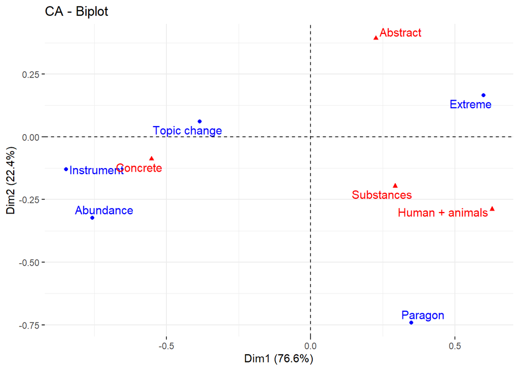

```r
tt = as.data.frame.matrix(t1)
tt_ca = ca(tt)
fviz_ca_biplot(tt_ca, repel = TRUE)
```

Topic_change, Instrument and Abudance meanings tend to relate to the concrete nouns. Extreme meaning may relate to Abstract nouns, Substances and Human+Animals. Paragon meanins relate both to Substances and Human+Animals.

Now let’s look if there is a dependency between `Semantics` and `Grammatical_number`.

```r
table(data$Semantics, data$Grammatical_number)
```

```
##
##                plur sing
##   Abundance       1   22
##   Extreme        24  997
##   Instrument      6  116
##   Paragon        17  307
##   Topic change  452 1115
```

```r
chisq.test(data$Semantics, data$Grammatical_number)
```

```
##
##  Pearson's Chi-squared test
##
## data:  data$Semantics and data$Grammatical_number
## X-squared = 368.36, df = 4, p-value < 2.2e-16
```

Yes, `Grammatical_number` is an important feature to predict `Semantics` (p-value is less then 0.05).

Now let’s find out if `Syntax` is important for the prediction of `Semantics`.

```r
t2 = table(data$Semantics, data$Syntax)
t2
```

```
##
##                Acc verb-governed Ins verb-governed Nom verb-governed
##   Abundance                    0                13                 1
##   Extreme                      0               438               215
##   Instrument                   0               114                 0
##   Paragon                      1                79                51
##   Topic change                 0                 1                 0
##
##                Nom/Ins verb-governed Ungoverned Ungoverned
##   Abundance                        0          8           1
##   Extreme                         56        312           0
##   Instrument                       2          6           0
##   Paragon                          7        186           0
##   Topic change                     0       1566           0
```

```r
chisq.test(data$Semantics, data$Syntax)
```

```
##
##  Pearson's Chi-squared test
##
## data:  data$Semantics and data$Syntax
## X-squared = 1975, df = 20, p-value < 2.2e-16
```

We can see that p-value is also less then 0.05, so we can conclude that `Syntax` also is an important feature. Let’s visualyze the correspondence analysis.

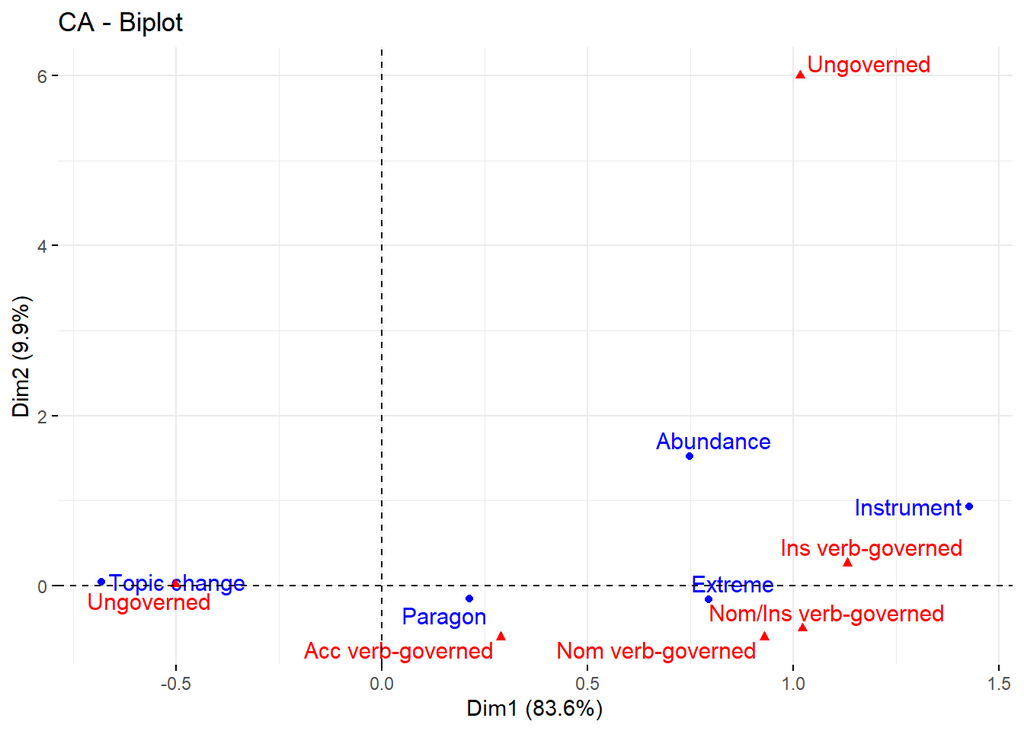

```r
tt = as.data.frame.matrix(t2)
tt_ca = ca(tt)
fviz_ca_biplot(tt_ca, repel = TRUE)
```

Topic_change tend to be Ungoverned, Paragon meanings are more likely to be governed by Accusative verbs. The rest of the meanings are located closely to Nominative and Instrumental verbs and can be governed by all of them.

Let’s conduct the rest of the Pearson’s Chi-squared tests (for all the features that weren’t mentioned earlier).

```r
chisq.test(data$Semantics, data$Pejorative)
```

```
##
##  Pearson's Chi-squared test
##
## data:  data$Semantics and data$Pejorative
## X-squared = 598.76, df = 8, p-value < 2.2e-16
```

```r
chisq.test(data$Semantics, data$Chained)
```

```
##
##  Pearson's Chi-squared test
##
## data:  data$Semantics and data$Chained
## X-squared = 328.43, df = 8, p-value < 2.2e-16
```

```r
chisq.test(data$Semantics, data$Author)
```

```
##
##  Pearson's Chi-squared test
##
## data:  data$Semantics and data$Author
## X-squared = 4531.3, df = 3752, p-value < 2.2e-16
```

```r
chisq.test(data$Semantics, data$Created)
```

```
##
##  Pearson's Chi-squared test
##
## data:  data$Semantics and data$Created
## X-squared = 2870.3, df = 1852, p-value < 2.2e-16
```

```r
chisq.test(data$Semantics, data$Publ_year)
```

```
##
##  Pearson's Chi-squared test
##
## data:  data$Semantics and data$Publ_year
## X-squared = 1339, df = 948, p-value = 6.647e-16
```

```r
chisq.test(data$Semantics, data$Verb_tags)
```

```
##
##  Pearson's Chi-squared test
##
## data:  data$Semantics and data$Verb_tags
## X-squared = 2323.5, df = 36, p-value < 2.2e-16
```

```r
chisq.test(data$Semantics, data$Left_context_tags)
```

```
##
##  Pearson's Chi-squared test
##
## data:  data$Semantics and data$Left_context_tags
## X-squared = 11579, df = 9028, p-value < 2.2e-16
```

```r
chisq.test(data$Semantics, data$Right_context_tags)
```

```
##
##  Pearson's Chi-squared test
##
## data:  data$Semantics and data$Right_context_tags
## X-squared = 11106, df = 10384, p-value = 4.644e-07
```

All the features are important due to the Pearson’s Chi-squared test. Though, we can finally reject our H_0 and accept H_1.

## 4. Searching for the most important variables

#### 4.1 Random Forest

First, let’s prepare the data.

```r
data <- transform(
  data,
  Semantics=as.factor(Semantics),
  Syntax=as.factor(Syntax),
  Semantic_classes_of_nouns=as.factor(Semantic_classes_of_nouns),
  Pejorative=as.factor(Pejorative),
  Chained=as.factor(Chained),
  Associated_verbs=as.factor(Associated_verbs),
  Author=as.factor(Author),
  Created=as.numeric(Created),
  Publ_year=as.numeric(Publ_year),
  Left_context_tags=as.factor(Left_context_tags),
  Right_context_tags=as.factor(Right_context_tags),
  Verb_tags=as.factor(Verb_tags),
  Left_context_tags_norm=as.factor(Left_context_tags_norm),
  Right_context_tags_norm=as.factor(Right_context_tags_norm),
  Grammatical_number=as.factor(Grammatical_number)
)
sapply(data, class)
```

```
##                 Semantics                    Syntax Semantic_classes_of_nouns
##                  "factor"                  "factor"                  "factor"
##                Pejorative                   Chained          Associated_verbs
##                  "factor"                  "factor"                  "factor"
##              Left_context                    Center             Right_context
##               "character"               "character"               "character"
##              Full_context                    Author                   Created
##               "character"                  "factor"                 "numeric"
##                 Publ_year         Left_context_tags        Right_context_tags
##                 "numeric"                  "factor"                  "factor"
##                 Verb_tags    Left_context_tags_norm   Right_context_tags_norm
##                  "factor"                  "factor"                  "factor"
##        Grammatical_number
##                  "factor"
```

```r
summary(data)
```

```
##         Semantics                      Syntax       Semantic_classes_of_nouns
##  Abundance   :  23   Acc verb-governed    :   1   Abstract       : 897
##  Extreme     :1021   Ins verb-governed    : 645   Concrete       :1279
##  Instrument  : 122   Nom verb-governed    : 267   Human + animals: 735
##  Paragon     : 324   Nom/Ins verb-governed:  65   Substances     : 146
##  Topic change:1567   Ungoverned           :2078
##                      Ungoverned           :   1
##
##  Pejorative Chained    Associated_verbs Left_context          Center
##  NaN:  54      :   1           :2134    Length:3057        Length:3057
##  no :2404   no :2712   быть    : 314    Class :character   Class :character
##  yes: 599   yes: 344   стоять  :  39    Mode  :character   Mode  :character
##                        вышибать:  35
##                        сидеть  :  34
##                        жить    :  18
##                        (Other) : 483
##  Right_context      Full_context                              Author
##  Length:3057        Length:3057                                  :  84
##  Class :character   Class :character   Д. Н. Мамин-Сибиряк       :  75
##  Mode  :character   Mode  :character   А. В. Амфитеатров         :  54
##                                        Андрей Белый              :  46
##                                        М. Е. Салтыков-Щедрин     :  44
##                                        П. И. Мельников-Печерский :  40
##                                        (Other)                   :2714
##     Created       Publ_year
##  Min.   : NA    Min.   : NA
##  1st Qu.: NA    1st Qu.: NA
##  Median : NA    Median : NA
##  Mean   :NaN    Mean   :NaN
##  3rd Qu.: NA    3rd Qu.: NA
##  Max.   : NA    Max.   : NA
##  NA's   :3057   NA's   :3057
##                                         Left_context_tags
##  []                                              : 561
##  [OpencorporaTag('CONJ')]                        : 100
##  [OpencorporaTag('CONJ,Prnt')]                   :  35
##  [OpencorporaTag('PRCL')]                        :  13
##  [OpencorporaTag('CONJ'), OpencorporaTag('CONJ')]:   9
##  [OpencorporaTag('ADVB')]                        :   7
##  (Other)                                         :2332
```

[output cut: 25 more lines]

```
##  [OpencorporaTag('NOUN,anim,masc sing,nomn')]                                                                                                                : 112
##  [OpencorporaTag('NOUN,inan,femn,Sgtm sing,accs')]                                                                                                           :  72
##  [OpencorporaTag('NOUN,inan,femn sing,nomn')]                                                                                                                :  67
##  [OpencorporaTag('NOUN,anim,femn sing,nomn')]                                                                                                                :  33
##  [OpencorporaTag('NOUN,inan,masc sing,nomn')]                                                                                                                :  29
##  [OpencorporaTag('NOUN,inan,femn sing,nomn'), OpencorporaTag('CONJ'), OpencorporaTag('NOUN,inan,femn sing,nomn'), OpencorporaTag('NOUN,inan,femn sing,nomn')]:  20
##  (Other)                                                                                                                                                     :2724
##  Grammatical_number
##  plur: 500
##  sing:2557
##
##
##
##
##
```

As a first step, we will use Random forest.

Random forest can’t deal with NA’s and categorical variables with more then 53 options, so we will exclude such features. Also, we will split data into train and test samples.

```r
sample = sample.split(data$Semantics, SplitRatio = 0.75)
train = subset(data, sample == TRUE, select = -c(Right_context, Left_context, Full_context, Center, Created, Publ_year, Associated_verbs, Author, Left_context_tags, Right_context_tags, Left_context_tags_norm, Right_context_tags_norm))
test  = subset(data, sample == FALSE, select = -c(Right_context, Left_context, Full_context, Center, Created, Publ_year, Associated_verbs, Author, Left_context_tags, Right_context_tags, Left_context_tags_norm, Right_context_tags_norm))
dim(train)
```

```
## [1] 2293    7
```

```r
dim(test)
```

```
## [1] 764   7
```

Now let’s train the Random forest.

```r
rf <- randomForest(
  Semantics ~ .,
  data=train, importance=TRUE)
rf
```

```
##
## Call:
##  randomForest(formula = Semantics ~ ., data = train, importance = TRUE)
##                Type of random forest: classification
##                      Number of trees: 500
## No. of variables tried at each split: 2
##
##         OOB estimate of  error rate: 21.02%
## Confusion matrix:
##              Abundance Extreme Instrument Paragon Topic change class.error
## Abundance            0       7          3       0            7   1.0000000
## Extreme              0     570          4      30          162   0.2558747
## Instrument           0      19         68       1            4   0.2608696
## Paragon              0     134          3      34           72   0.8600823
## Topic change         0      22          0      14         1139   0.0306383
```

As we can see from the confusion matrix, `Abundance` class’s error equals to 100%. Probably we observe such a poor result due to the class disbalance: `Abudance` has only 17 examples in a train sample.

Let’s now look at the feature importance table.

```r
importance(rf)
```

```
##                            Abundance  Extreme Instrument   Paragon Topic change
## Syntax                     1.0010015 21.45816 43.3725999 -2.045427    52.883689
## Semantic_classes_of_nouns -0.7279924 44.39583 35.7174994 -7.771612     3.593803
## Pejorative                -1.7221157 31.82276  9.0357197 14.823979    29.781405
## Chained                    0.0000000 14.70870  8.2842812  7.375178     7.353429
## Verb_tags                  0.1324556 33.45290 24.7935486 -4.756542    22.603950
## Grammatical_number        -0.7146504 17.04206 -0.5217706 -4.636624     1.167492
##                           MeanDecreaseAccuracy MeanDecreaseGini
## Syntax                                42.32192        257.05116
## Semantic_classes_of_nouns             44.97466        120.80632
## Pejorative                            39.83922         73.83715
## Chained                               17.50003         22.94486
## Verb_tags                             33.48962        224.28679
## Grammatical_number                    15.45085         26.75938
```

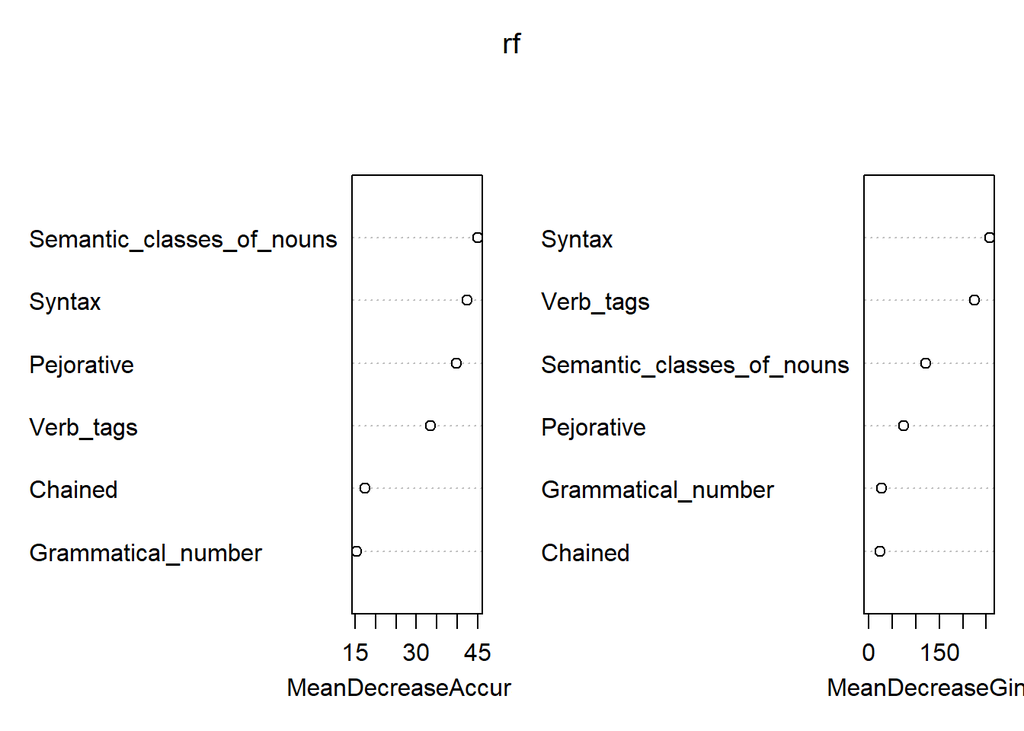

```r
varImpPlot(rf)
```

We can understand that `Chained` and `Grammatical_number` are the least important variables for prefiction of the `Semantics`. At the same time, `Syntax` and `Semantic_classes_of_nouns` are the leaders due to different scales, which is perfectly consistent to our H_2.

Now let’s test our model on a test sample.

```r
pred = predict(rf, newdata=test[-1])
cm = table(test[,1], pred)
cm
```

```
##               pred
##                Abundance Extreme Instrument Paragon Topic change
##   Abundance            0       4          0       0            2
##   Extreme              0     191          1      11           52
##   Instrument           0      10         19       0            1
##   Paragon              0      36          2      10           33
##   Topic change         0       4          0       7          381
```

As we can see, `Abudance` examples are not predicted correctly at all; `Extreme` is partially mixed with `Topic change`; `Instrument` is predicted quite accurate; `Paragon` is mixed with `Extreme` and `Topic change`, so almost none of the examples were predicted correctly for this class; `Topic change` is predicted almost perfect.

### 4.2. Linear models

Now let’s choose one semantics type and treat our task as 2 class classification task (our chosen class vs all the other classes). `Topic change` has the smallest error value in Random forest model and the biggest number of examples, though we will pick it. Let’s first create a new dataset where only two classes are present.

```r
data_lr <- data
data_lr <- transform(
  data_lr,
  Semantics=as.character(Semantics))
sapply(data_lr, class)
```

```
##                 Semantics                    Syntax Semantic_classes_of_nouns
##               "character"                  "factor"                  "factor"
##                Pejorative                   Chained          Associated_verbs
##                  "factor"                  "factor"                  "factor"
##              Left_context                    Center             Right_context
##               "character"               "character"               "character"
##              Full_context                    Author                   Created
##               "character"                  "factor"                 "numeric"
##                 Publ_year         Left_context_tags        Right_context_tags
##                 "numeric"                  "factor"                  "factor"
##                 Verb_tags    Left_context_tags_norm   Right_context_tags_norm
##                  "factor"                  "factor"                  "factor"
##        Grammatical_number
##                  "factor"
```

```r
data_lr[!data_lr$Semantics == 'Topic change',]$Semantics <- 0
data_lr[data_lr$Semantics == 'Topic change',]$Semantics <- 1
data_lr <- transform(
  data_lr,
  Semantics=as.numeric(Semantics))
sapply(data_lr, class)
```

```
##                 Semantics                    Syntax Semantic_classes_of_nouns
##                 "numeric"                  "factor"                  "factor"
##                Pejorative                   Chained          Associated_verbs
##                  "factor"                  "factor"                  "factor"
##              Left_context                    Center             Right_context
##               "character"               "character"               "character"
##              Full_context                    Author                   Created
##               "character"                  "factor"                 "numeric"
##                 Publ_year         Left_context_tags        Right_context_tags
##                 "numeric"                  "factor"                  "factor"
##                 Verb_tags    Left_context_tags_norm   Right_context_tags_norm
##                  "factor"                  "factor"                  "factor"
##        Grammatical_number
##                  "factor"
```

```r
data_lr[1:5,]
```

|  | Semantics | Syntax | Semantic_classes_of_nouns | Pejorative | Chained | Associated_verbs | Left_context | Center | Right_context | Full_context | Author | Created | Publ_year | Left_context_tags | Right_context_tags | Verb_tags | Left_context_tags_norm | Right_context_tags_norm | Grammatical_number |
| --- | --- | --- | --- | --- | --- | --- | --- | --- | --- | --- | --- | --- | --- | --- | --- | --- | --- | --- | --- |
| 1 | 0 | Ins verb-governed | Concrete | no | no |  | Рожь выгнало уже | камыш | камышом, сизые овсы кудряво колосились | Рожь выгнало уже камыш-камышом, сизые овсы кудряво колосились, лен убрался в голубенькие платочки, и на гречиху начала летать пчела. | С. Н. Сергеев-Ценский | NA | NA | [OpencorporaTag('NOUN,inan,femn sing,nomn'), OpencorporaTag('VERB,perf,tran neut,sing,past,indc'), OpencorporaTag('ADVB')] | [OpencorporaTag('NOUN,inan,masc sing,ablt'), OpencorporaTag('ADJF,Qual plur,nomn'), OpencorporaTag('NOUN,inan,masc plur,nomn'), OpencorporaTag('ADJS,Qual neut,sing'), OpencorporaTag('VERB,impf,intr pl… | [] | [OpencorporaTag('NOUN,inan,femn sing,nomn'), OpencorporaTag('INFN,perf,tran'), OpencorporaTag('ADVB')] | [OpencorporaTag('NOUN,inan,masc sing,nomn'), OpencorporaTag('ADJF,Qual masc,sing,nomn'), OpencorporaTag('NOUN,inan,masc sing,nomn'), OpencorporaTag('ADJF,Qual masc,sing,nomn'), OpencorporaTag('INFN,im… | sing |
| 2 | 0 | Ins verb-governed | Concrete | no | no | уродиться | которых уродилось в Потаенном колке | мост | мостом, как выражался старый пчеляк | Слух о груздях, которых уродилось в Потаенном колке мост мостом, как выражался старый пчеляк, живший в лесу со своими пчелами, взволновал тетушку и моего отца, которые, очень любили брать грибы и особ… | С. Т. Аксаков | NA | NA | [OpencorporaTag('ADJF,Apro,Subx,Anph plur,gent'), OpencorporaTag('VERB,perf,intr neut,sing,past,indc'), OpencorporaTag('PREP'), OpencorporaTag('ADJF,Qual masc,sing,loct'), OpencorporaTag('NOUN,inan,fe… | [OpencorporaTag('NOUN,inan,masc sing,ablt'), OpencorporaTag('CONJ'), OpencorporaTag('VERB,impf,intr masc,sing,past,indc'), OpencorporaTag('ADJF,Qual masc,sing,nomn'), OpencorporaTag('NOUN,anim,masc si… | [OpencorporaTag('INFN,perf,intr')] | [OpencorporaTag('ADJF,Apro,Subx,Anph masc,sing,nomn'), OpencorporaTag('INFN,perf,intr'), OpencorporaTag('PREP'), OpencorporaTag('ADJF,Qual masc,sing,nomn'), OpencorporaTag('NOUN,inan,femn sing,nomn')] | [OpencorporaTag('NOUN,inan,masc sing,nomn'), OpencorporaTag('CONJ'), OpencorporaTag('INFN,impf,intr'), OpencorporaTag('ADJF,Qual masc,sing,nomn'), OpencorporaTag('NOUN,anim,masc sing,nomn')] | sing |
| 3 | 0 | Ins verb-governed | Concrete | no | no | пойти | Женится ребята пойдут | мост | мостом, как груздочки после дождя | Женится ребята пойдут мост-мостом, как груздочки после дождя, один другого ядреней, и жена не чахнет. | П. П. Бажов | NA | NA | [OpencorporaTag('VERB,perf,intr sing,3per,futr,indc'), OpencorporaTag('NOUN,anim,GNdr,Pltm plur,nomn'), OpencorporaTag('VERB,perf,intr plur,3per,futr,indc')] | [OpencorporaTag('NOUN,inan,masc sing,ablt'), OpencorporaTag('CONJ'), OpencorporaTag('NOUN,anim,femn sing,gent'), OpencorporaTag('PREP'), OpencorporaTag('NOUN,inan,masc sing,gent')] | [OpencorporaTag('INFN,perf,intr')] | [OpencorporaTag('INFN,perf,intr'), OpencorporaTag('NOUN,anim,GNdr,Pltm plur,nomn'), OpencorporaTag('INFN,perf,intr')] | [OpencorporaTag('NOUN,inan,masc sing,nomn'), OpencorporaTag('CONJ'), OpencorporaTag('NOUN,anim,femn sing,nomn'), OpencorporaTag('PREP'), OpencorporaTag('NOUN,inan,masc sing,nomn')] | sing |
| 4 | 0 | Ins verb-governed | Concrete | yes | no | выбраться | праздник в большую деревню выберутся | орда | ордой. | Бывало, к нам в праздник в большую деревню выберутся орда ордой. | Федор Абрамов | NA | NA | [OpencorporaTag('NOUN,inan,masc sing,nomn'), OpencorporaTag('PREP'), OpencorporaTag('ADJF,Qual femn,sing,accs'), OpencorporaTag('NOUN,inan,femn sing,accs'), OpencorporaTag('VERB,perf,intr plur,3per,fu… | [OpencorporaTag('NOUN,inan,femn sing,ablt')] | [OpencorporaTag('INFN,perf,intr')] | [OpencorporaTag('NOUN,inan,masc sing,nomn'), OpencorporaTag('PREP'), OpencorporaTag('ADJF,Qual femn,sing,gent'), OpencorporaTag('NOUN,inan,femn sing,nomn'), OpencorporaTag('INFN,perf,intr')] | [OpencorporaTag('NOUN,inan,femn sing,nomn')] | sing |
| 5 | 0 | Ins verb-governed | Concrete | no | no | стоять | внучатными самому Гвоздилову. Вот они | стена | стеной и стоят. Проштрафится, бывало | Хлобыстовские родня Дракиным, Дракины в свойстве с Расплюевыми, а Расплюевы чуть ли не приходятся внучатными самому Гвоздилову. Вот они стена стеной и стоят. Проштрафится, бывало, Дракин сейчас к Расп… | М. Е. Салтыков-Щедрин | NA | NA | [OpencorporaTag('ADJF,Qual plur,ablt'), OpencorporaTag('ADJF,Apro masc,sing,datv'), OpencorporaTag('NOUN,anim,masc,Sgtm,Surn sing,datv'), OpencorporaTag('PRCL'), OpencorporaTag('NPRO,3per,Anph plur,no… | [OpencorporaTag('NOUN,inan,femn sing,ablt'), OpencorporaTag('CONJ'), OpencorporaTag('VERB,impf,intr plur,3per,pres,indc'), OpencorporaTag('VERB,perf,intr sing,3per,futr,indc'), OpencorporaTag('VERB,im… | [OpencorporaTag('INFN,impf,intr')] | [OpencorporaTag('ADJF,Qual masc,sing,nomn'), OpencorporaTag('ADJF,Apro masc,sing,nomn'), OpencorporaTag('ADJS,Qual masc,sing'), OpencorporaTag('PRCL'), OpencorporaTag('NPRO,3per,Anph plur,nomn')] | [OpencorporaTag('NOUN,inan,masc sing,gent'), OpencorporaTag('CONJ'), OpencorporaTag('INFN,impf,intr'), OpencorporaTag('INFN,perf,intr'), OpencorporaTag('INFN,impf,intr')] | sing |

```r
fit1 <- lm(data = data_lr, Semantics ~ Syntax)
summary(fit1)
```

```
##
## Call:
## lm(formula = Semantics ~ Syntax, data = data_lr)
##
## Residuals:
##      Min       1Q   Median       3Q      Max
## -0.75361 -0.00155  0.24639  0.24639  0.99845
##
## Coefficients:
##                               Estimate Std. Error t value Pr(>|t|)
## (Intercept)                  5.289e-15  3.561e-01   0.000   1.0000
## SyntaxIns verb-governed      1.550e-03  3.564e-01   0.004   0.9965
## SyntaxNom verb-governed      8.312e-14  3.567e-01   0.000   1.0000
## SyntaxNom/Ins verb-governed -1.101e-13  3.588e-01   0.000   1.0000
## SyntaxUngoverned             7.536e-01  3.562e-01   2.116   0.0344 *
## SyntaxUngoverned             1.250e-15  5.036e-01   0.000   1.0000
## ---
## Signif. codes:  0 '***' 0.001 '**' 0.01 '*' 0.05 '.' 0.1 ' ' 1
##
## Residual standard error: 0.3561 on 3051 degrees of freedom
## Multiple R-squared:  0.4935, Adjusted R-squared:  0.4927
## F-statistic: 594.5 on 5 and 3051 DF,  p-value: < 2.2e-16
```

It seems that only `Ungoverned` value is the important predictor.

```r
fit2 <- lm(data = data_lr, Semantics ~ Syntax + Pejorative)
summary(fit2)
```

```
##
## Call:
## lm(formula = Semantics ~ Syntax + Pejorative, data = data_lr)
##
## Residuals:
##      Min       1Q   Median       3Q      Max
## -0.79620 -0.09678  0.20380  0.20380  1.20637
##
## Coefficients:
##                               Estimate Std. Error t value Pr(>|t|)
## (Intercept)                 -1.272e-01  3.396e-01  -0.375 0.707895
## SyntaxIns verb-governed      9.678e-02  3.367e-01   0.287 0.773805
## SyntaxNom verb-governed      1.102e-01  3.371e-01   0.327 0.743656
## SyntaxNom/Ins verb-governed  1.399e-01  3.391e-01   0.413 0.679898
## SyntaxUngoverned             7.962e-01  3.365e-01   2.366 0.018038 *
## SyntaxUngoverned            -9.889e-14  4.758e-01   0.000 1.000000
## Pejorativeno                 1.272e-01  4.630e-02   2.748 0.006024 **
## Pejorativeyes               -1.759e-01  4.793e-02  -3.670 0.000247 ***
## ---
## Signif. codes:  0 '***' 0.001 '**' 0.01 '*' 0.05 '.' 0.1 ' ' 1
##
## Residual standard error: 0.3364 on 3049 degrees of freedom
## Multiple R-squared:  0.5482, Adjusted R-squared:  0.5472
## F-statistic: 528.5 on 7 and 3049 DF,  p-value: < 2.2e-16
```

The p-values of `Syntax` options changed, but still only `Syntax:Ungoverned` is important. Also, we can infer that both `Pejorative:yes` and `Pejorative:no` are significant.

```r
fit3 <- lm(data = data_lr, Semantics ~ Syntax + Pejorative + Verb_tags)
summary(fit3)
```

```
##
## Call:
## lm(formula = Semantics ~ Syntax + Pejorative + Verb_tags, data = data_lr)
##
## Residuals:
##     Min      1Q  Median      3Q     Max
## -0.8558 -0.1173  0.2022  0.2022  1.1827
##
## Coefficients:
##                                                                                     Estimate
## (Intercept)                                                                        -0.110570
## SyntaxIns verb-governed                                                             0.073248
## SyntaxNom verb-governed                                                             0.045086
## SyntaxNom/Ins verb-governed                                                         0.086019
## SyntaxUngoverned                                                                    0.783572
## SyntaxUngoverned                                                                   -0.072210
## Pejorativeno                                                                        0.124779
## Pejorativeyes                                                                      -0.190763
## Verb_tags[OpencorporaTag('INFN,impf,intr')]                                         0.058002
## Verb_tags[OpencorporaTag('INFN,impf,tran'), OpencorporaTag('NPRO,Anph sing,accs')]  0.228085
## Verb_tags[OpencorporaTag('INFN,impf,tran')]                                        -0.014209
## Verb_tags[OpencorporaTag('INFN,perf,intr')]                                         0.045405
## Verb_tags[OpencorporaTag('INFN,perf,tran'), OpencorporaTag('NPRO,Anph sing,accs')] -0.087457
## Verb_tags[OpencorporaTag('INFN,perf,tran')]                                        -0.061626
## Verb_tags[OpencorporaTag('NOUN,inan,femn sing,gent')]                              -0.073376
## Verb_tags[OpencorporaTag('VERB,impf,tran sing,impr,excl')]                         -0.001531
## Verb_tags[OpencorporaTag('VERB,perf,tran sing,impr,excl')]                          0.067121
##                                                                                    Std. Error
## (Intercept)                                                                          0.343666
## SyntaxIns verb-governed                                                              0.337916
## SyntaxNom verb-governed                                                              0.339230
## SyntaxNom/Ins verb-governed                                                          0.340984
## SyntaxUngoverned                                                                     0.340693
## SyntaxUngoverned                                                                     0.477133
## Pejorativeno                                                                         0.046268
## Pejorativeyes                                                                        0.048062
## Verb_tags[OpencorporaTag('INFN,impf,intr')]                                          0.049089
## Verb_tags[OpencorporaTag('INFN,impf,tran'), OpencorporaTag('NPRO,Anph sing,accs')]   0.199270
## Verb_tags[OpencorporaTag('INFN,impf,tran')]                                          0.055308
## Verb_tags[OpencorporaTag('INFN,perf,intr')]                                          0.051140
```

[output cut: 50 more lines]

```
## Verb_tags[OpencorporaTag('INFN,impf,intr')]
## Verb_tags[OpencorporaTag('INFN,impf,tran'), OpencorporaTag('NPRO,Anph sing,accs')]
## Verb_tags[OpencorporaTag('INFN,impf,tran')]
## Verb_tags[OpencorporaTag('INFN,perf,intr')]
## Verb_tags[OpencorporaTag('INFN,perf,tran'), OpencorporaTag('NPRO,Anph sing,accs')]
## Verb_tags[OpencorporaTag('INFN,perf,tran')]
## Verb_tags[OpencorporaTag('NOUN,inan,femn sing,gent')]
## Verb_tags[OpencorporaTag('VERB,impf,tran sing,impr,excl')]
## Verb_tags[OpencorporaTag('VERB,perf,tran sing,impr,excl')]
## ---
## Signif. codes:  0 '***' 0.001 '**' 0.01 '*' 0.05 '.' 0.1 ' ' 1
##
## Residual standard error: 0.3361 on 3040 degrees of freedom
## Multiple R-squared:  0.5504, Adjusted R-squared:  0.548
## F-statistic: 232.6 on 16 and 3040 DF,  p-value: < 2.2e-16
```

Nothing changed: none of the `Verb_tags` variants are significant.

```r
fit4 <- lm(data = data_lr, Semantics ~ Syntax + Pejorative + Verb_tags + Chained)
summary(fit4)
```

```
##
## Call:
## lm(formula = Semantics ~ Syntax + Pejorative + Verb_tags + Chained,
##     data = data_lr)
##
## Residuals:
##     Min      1Q  Median      3Q     Max
## -0.9947 -0.1093  0.1615  0.2440  1.1716
##
## Coefficients:
##                                                                                     Estimate
## (Intercept)                                                                        -0.092593
## SyntaxIns verb-governed                                                             0.307441
## SyntaxNom verb-governed                                                             0.281300
## SyntaxNom/Ins verb-governed                                                         0.316948
## SyntaxUngoverned                                                                    0.981211
## SyntaxUngoverned                                                                   -0.066691
## Pejorativeno                                                                        0.111382
## Pejorativeyes                                                                      -0.185527
## Verb_tags[OpencorporaTag('INFN,impf,intr')]                                         0.053212
## Verb_tags[OpencorporaTag('INFN,impf,tran'), OpencorporaTag('NPRO,Anph sing,accs')]  0.214672
## Verb_tags[OpencorporaTag('INFN,impf,tran')]                                        -0.013478
## Verb_tags[OpencorporaTag('INFN,perf,intr')]                                         0.043120
## Verb_tags[OpencorporaTag('INFN,perf,tran'), OpencorporaTag('NPRO,Anph sing,accs')] -0.082237
## Verb_tags[OpencorporaTag('INFN,perf,tran')]                                        -0.057997
## Verb_tags[OpencorporaTag('NOUN,inan,femn sing,gent')]                              -0.069167
## Verb_tags[OpencorporaTag('VERB,impf,tran sing,impr,excl')]                         -0.001475
## Verb_tags[OpencorporaTag('VERB,perf,tran sing,impr,excl')]                          0.063841
## Chainedno                                                                          -0.243993
## Chainedyes                                                                         -0.005311
##                                                                                    Std. Error
## (Intercept)                                                                          0.469747
## SyntaxIns verb-governed                                                              0.330502
## SyntaxNom verb-governed                                                              0.331792
## SyntaxNom/Ins verb-governed                                                          0.333478
## SyntaxUngoverned                                                                     0.333052
## SyntaxUngoverned                                                                     0.465884
## Pejorativeno                                                                         0.045190
## Pejorativeyes                                                                        0.046931
## Verb_tags[OpencorporaTag('INFN,impf,intr')]                                          0.047933
```

[output cut: 61 more lines]

```
## Verb_tags[OpencorporaTag('INFN,impf,tran')]
## Verb_tags[OpencorporaTag('INFN,perf,intr')]
## Verb_tags[OpencorporaTag('INFN,perf,tran'), OpencorporaTag('NPRO,Anph sing,accs')]
## Verb_tags[OpencorporaTag('INFN,perf,tran')]
## Verb_tags[OpencorporaTag('NOUN,inan,femn sing,gent')]
## Verb_tags[OpencorporaTag('VERB,impf,tran sing,impr,excl')]
## Verb_tags[OpencorporaTag('VERB,perf,tran sing,impr,excl')]
## Chainedno
## Chainedyes
## ---
## Signif. codes:  0 '***' 0.001 '**' 0.01 '*' 0.05 '.' 0.1 ' ' 1
##
## Residual standard error: 0.3282 on 3038 degrees of freedom
## Multiple R-squared:  0.5716, Adjusted R-squared:  0.5691
## F-statistic: 225.2 on 18 and 3038 DF,  p-value: < 2.2e-16
```

`Chained` is also not important in prediction of the `Semantics`.

```r
fit5 <- lm(data = data_lr, Semantics ~ Syntax + Pejorative + Verb_tags + Chained + Semantic_classes_of_nouns)
summary(fit5)
```

```
##
## Call:
## lm(formula = Semantics ~ Syntax + Pejorative + Verb_tags + Chained +
##     Semantic_classes_of_nouns, data = data_lr)
##
## Residuals:
##     Min      1Q  Median      3Q     Max
## -1.0390 -0.1246  0.1169  0.1971  1.2012
##
## Coefficients:
##                                                                                    Estimate
## (Intercept)                                                                        -0.22140
## SyntaxIns verb-governed                                                             0.33280
## SyntaxNom verb-governed                                                             0.31238
## SyntaxNom/Ins verb-governed                                                         0.34495
## SyntaxUngoverned                                                                    1.02086
## SyntaxUngoverned                                                                   -0.12412
## Pejorativeno                                                                        0.10455
## Pejorativeyes                                                                      -0.12925
## Verb_tags[OpencorporaTag('INFN,impf,intr')]                                         0.10602
## Verb_tags[OpencorporaTag('INFN,impf,tran'), OpencorporaTag('NPRO,Anph sing,accs')]  0.30314
## Verb_tags[OpencorporaTag('INFN,impf,tran')]                                        -0.01810
## Verb_tags[OpencorporaTag('INFN,perf,intr')]                                         0.10196
## Verb_tags[OpencorporaTag('INFN,perf,tran'), OpencorporaTag('NPRO,Anph sing,accs')]  0.06934
## Verb_tags[OpencorporaTag('INFN,perf,tran')]                                        -0.02250
## Verb_tags[OpencorporaTag('NOUN,inan,femn sing,gent')]                              -0.02881
## Verb_tags[OpencorporaTag('VERB,impf,tran sing,impr,excl')]                          0.05233
## Verb_tags[OpencorporaTag('VERB,perf,tran sing,impr,excl')]                          0.13211
## Chainedno                                                                          -0.17693
## Chainedyes                                                                          0.03896
## Semantic_classes_of_nounsConcrete                                                   0.09599
## Semantic_classes_of_nounsHuman + animals                                           -0.10836
## Semantic_classes_of_nounsSubstances                                                -0.09881
##                                                                                    Std. Error
## (Intercept)                                                                           0.45784
## SyntaxIns verb-governed                                                               0.32180
## SyntaxNom verb-governed                                                               0.32309
## SyntaxNom/Ins verb-governed                                                           0.32469
## SyntaxUngoverned                                                                      0.32432
## SyntaxUngoverned                                                                      0.45359
```

[output cut: 76 more lines]

```
## Verb_tags[OpencorporaTag('INFN,perf,tran')]
## Verb_tags[OpencorporaTag('NOUN,inan,femn sing,gent')]
## Verb_tags[OpencorporaTag('VERB,impf,tran sing,impr,excl')]
## Verb_tags[OpencorporaTag('VERB,perf,tran sing,impr,excl')]
## Chainedno
## Chainedyes
## Semantic_classes_of_nounsConcrete                                                  ***
## Semantic_classes_of_nounsHuman + animals                                           ***
## Semantic_classes_of_nounsSubstances                                                ***
## ---
## Signif. codes:  0 '***' 0.001 '**' 0.01 '*' 0.05 '.' 0.1 ' ' 1
##
## Residual standard error: 0.3195 on 3035 degrees of freedom
## Multiple R-squared:  0.5944, Adjusted R-squared:  0.5916
## F-statistic: 211.8 on 21 and 3035 DF,  p-value: < 2.2e-16
```

`Semantic_classes_of_nouns` turned out to be significant. Moreover, two of the `Verb_tags` became significant: `[OpencorporaTag('INFN,perf,intr')]` and `[OpencorporaTag('INFN,impf,intr')]`.

```r
fit6 <- lm(data = data_lr, Semantics ~ Syntax + Pejorative + Verb_tags + Chained + Semantic_classes_of_nouns + Grammatical_number)
summary(fit6)
```

```
##
## Call:
## lm(formula = Semantics ~ Syntax + Pejorative + Verb_tags + Chained +
##     Semantic_classes_of_nouns + Grammatical_number, data = data_lr)
##
## Residuals:
##      Min       1Q   Median       3Q      Max
## -1.16248 -0.12567  0.05603  0.24426  1.19889
##
## Coefficients:
##                                                                                    Estimate
## (Intercept)                                                                        -0.07474
## SyntaxIns verb-governed                                                             0.48682
## SyntaxNom verb-governed                                                             0.46064
## SyntaxNom/Ins verb-governed                                                         0.49735
## SyntaxUngoverned                                                                    1.12335
## SyntaxUngoverned                                                                    0.07451
## Pejorativeno                                                                        0.09767
## Pejorativeyes                                                                      -0.11152
## Verb_tags[OpencorporaTag('INFN,impf,intr')]                                         0.07459
## Verb_tags[OpencorporaTag('INFN,impf,tran'), OpencorporaTag('NPRO,Anph sing,accs')]  0.26600
## Verb_tags[OpencorporaTag('INFN,impf,tran')]                                        -0.03913
## Verb_tags[OpencorporaTag('INFN,perf,intr')]                                         0.06710
## Verb_tags[OpencorporaTag('INFN,perf,tran'), OpencorporaTag('NPRO,Anph sing,accs')]  0.05681
## Verb_tags[OpencorporaTag('INFN,perf,tran')]                                        -0.05509
## Verb_tags[OpencorporaTag('NOUN,inan,femn sing,gent')]                              -0.06417
## Verb_tags[OpencorporaTag('VERB,impf,tran sing,impr,excl')]                         -0.01531
## Verb_tags[OpencorporaTag('VERB,perf,tran sing,impr,excl')]                          0.11477
## Chainedno                                                                          -0.24426
## Chainedyes                                                                         -0.02575
## Semantic_classes_of_nounsConcrete                                                   0.04195
## Semantic_classes_of_nounsHuman + animals                                           -0.13406
## Semantic_classes_of_nounsSubstances                                                -0.10855
## Grammatical_numbersing                                                             -0.18823
##                                                                                    Std. Error
## (Intercept)                                                                           0.44898
## SyntaxIns verb-governed                                                               0.31573
## SyntaxNom verb-governed                                                               0.31698
## SyntaxNom/Ins verb-governed                                                           0.31856
## SyntaxUngoverned                                                                      0.31804
```

[output cut: 81 more lines]

```
## Verb_tags[OpencorporaTag('NOUN,inan,femn sing,gent')]
## Verb_tags[OpencorporaTag('VERB,impf,tran sing,impr,excl')]
## Verb_tags[OpencorporaTag('VERB,perf,tran sing,impr,excl')]
## Chainedno
## Chainedyes
## Semantic_classes_of_nounsConcrete                                                  **
## Semantic_classes_of_nounsHuman + animals                                           ***
## Semantic_classes_of_nounsSubstances                                                ***
## Grammatical_numbersing                                                             ***
## ---
## Signif. codes:  0 '***' 0.001 '**' 0.01 '*' 0.05 '.' 0.1 ' ' 1
##
## Residual standard error: 0.3132 on 3034 degrees of freedom
## Multiple R-squared:  0.6104, Adjusted R-squared:  0.6076
## F-statistic: 216.1 on 22 and 3034 DF,  p-value: < 2.2e-16
```

Grammatical number is an important feature while Verb tags isn’t. The rest of the results remain the same.

Now let’s look at the variable importance of the fit6.

```r
imp <- as.data.frame(varImp(fit6))
imp <- data.frame(overall = imp$Overall,
           names   = rownames(imp))
imp <- imp[order(imp$overall,decreasing = T),]
imp[1:5,]
```

|  | overall | names |
| --- | --- | --- |
| 22 | 11.167145 | Grammatical_numbersing |
| 20 | 7.494736 | Semantic_classes_of_nounsHuman + animals |
| 21 | 3.826101 | Semantic_classes_of_nounsSubstances |
| 4 | 3.532097 | SyntaxUngoverned |
| 19 | 2.741597 | Semantic_classes_of_nounsConcrete |

We can see that linear model treats `Grammatical_number`, `Semantic_classes_of_nouns` and `Syntax` as 3 most important features for predicting `Topic_change`. Let’s try to predict it using the latest model.

```r
sample = sample.split(data_lr$Semantics, SplitRatio = 0.75)
train = subset(data_lr, sample == TRUE, select = -c(Right_context, Left_context, Full_context, Center, Created, Publ_year, Associated_verbs, Author, Left_context_tags, Right_context_tags, Left_context_tags_norm, Right_context_tags_norm))
test  = subset(data_lr, sample == FALSE, select = -c(Right_context, Left_context, Full_context, Center, Created, Publ_year, Associated_verbs, Author, Left_context_tags, Right_context_tags, Left_context_tags_norm, Right_context_tags_norm))
dim(train)
```

```
## [1] 2293    7
```

```r
dim(test)
```

```
## [1] 764   7
```

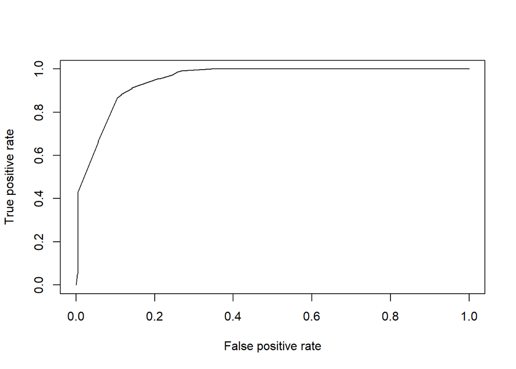

```r
p <- predict(fit6, newdata=test[-1], type="response")
pr <- prediction(p, test$Semantics)
prf <- performance(pr, measure = "tpr", x.measure = "fpr")
plot(prf)
```

```r
auc <- performance(pr, measure = "auc")
auc <- auc@y.values[[1]]
auc
```

```
## [1] 0.9498779
```